# Final

Rodrigo Grijalba

11/15/2021

# Estructura geográfica y socioespacial de Lima Metropolitana según las decisiones de transporte

## Rodrigo Grijalba

La ciudad de Lima es una metrópolis que consta de alrededor de 10 millones de habitantes. Esto trae consigo retos para la planificación urbana, entre ellos el de lograr una infraestructura de transporte eficiente. Asimismo, la evolución de Lima, como descrita por Pereyra (2006), ha causado un ritmo de crecimiento distinto a lo que se ha visto en países desarrollados, explicado por el modelo de ciudad geocéntrica (MCG) (Alonso, 1964; Muth, 1969; y Mills, 1967. Esta distinción recae en que el MCG predice que los grupos con menores ingresos se concentrarían al centro de la ciudad, mientras que lo opuesto sucede en Lima (Pereyra, 2006). Estos hechos nos llevan a la pregunta: ¿cómo se refleja el crecimiento desigual de Lima en las decisiones de transporte de sus habitantes? Se esperaría que el transporte de las personas con mayores ingresos tengan tiempos de transporte menores, y que exista una diferencia marcada en las decisiones sobre los modos de transporte, ahondando las desigualdades.

Para empezar, es necesario averiguar la estructura geoespacial de Lima Metropolitana en términos de actividad económica, puesto que las hipótesis planteadas se apoyan en el supuesto de que Lima es una ciudad monocéntrica.

En la siguiente tabla, es posible ver que el distrito con mayor concurrencia para fines laborales o educativos es el Distrito de Lima:

```
##                   Distrito   Cantidad
## 1                    LURIN  71458.333
## 2                    ANCON  40195.312
## 3               SAN ISIDRO 196510.417
## 4        MAGDALENA DEL MAR  62526.042
## 5                SAN BORJA  98255.208
## 6                    LINCE  58059.896
## 7        SANTIAGO DE SURCO 299231.771
## 8             PUEBLO LIBRE  49127.604
## 9               SANTA ROSA   4466.146
## 10              CARABAYLLO  62526.042
## 11             JESUS MARIA  62526.042
## 12                PUCUSANA  44661.458
## 13     SANTA MARIA DEL MAR      0.000
## 14              CHORRILLOS 151848.958
```

[output cut: 30 more lines]

Esto se ve reflejado en una estructura monocéntrica para la ciudad de Lima, ilustrada en el siguiente mapa, que muestra al distrito de Lima nuevamente como el más concurrido para fines laborales y educativos:

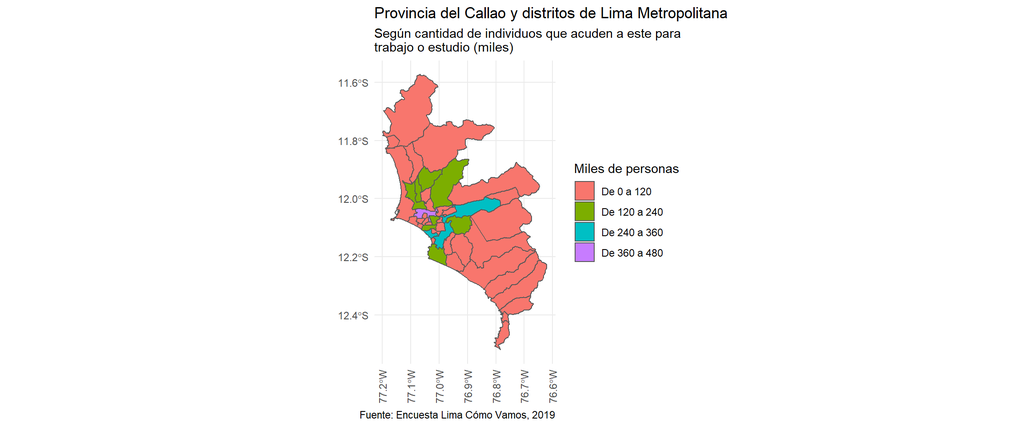

Es posible concluir que la ciudad tiene carácter monocéntrico. Esto nos conlleva a analizar el tiempo que toman las personas de distintos niveles socioeconómicos para desplazarse a sus centros de trabajo o estudio. Estos están ilustrados en la siguiente figura:

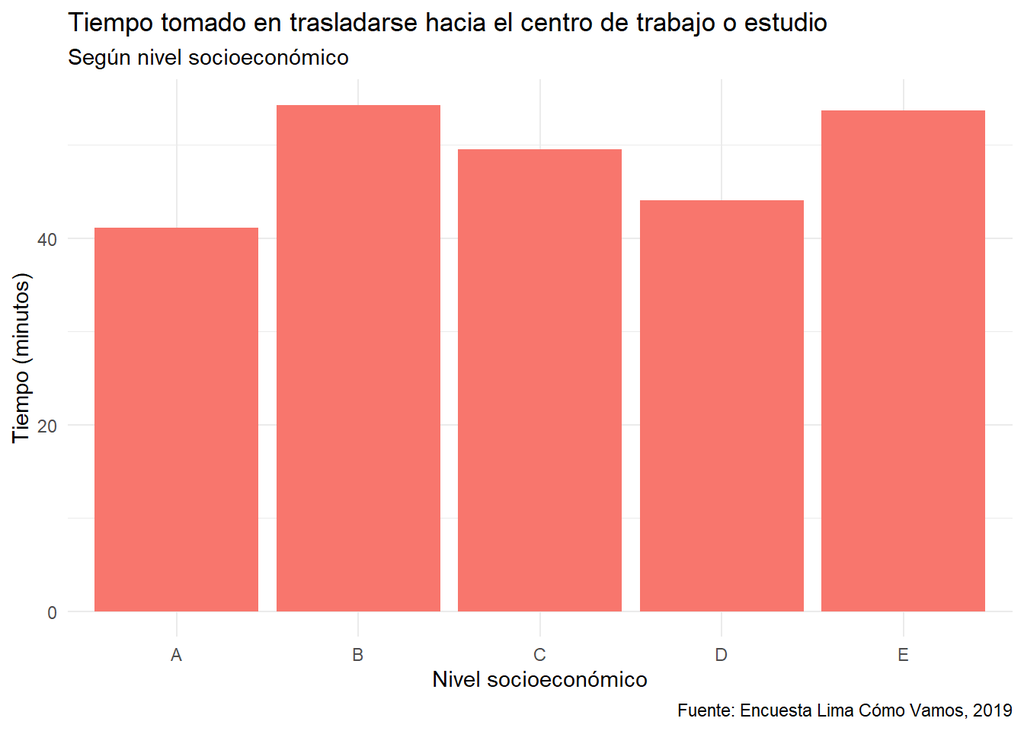

Si bien las personas del nivel socioeconómico A son quienes, en promedio, tienen el menor tiempo de transporte, no existe una relación visible entre nivel socioeconómico y tiempo de transporte.

Ahora se pasará a analizar las decisiones de transporte y, posteriormente, su relación con el nivel socioeconómico. El transporte masivo es el más utilizado en Lima Metropolitana, específicamente los buses y las combis, como es posible ver en la siguiente figura. A estos les sigue el desplazamiento a pie y el uso de automóviles propios.

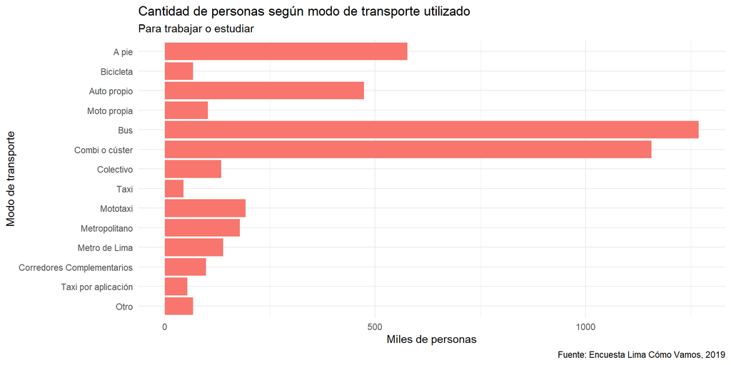

Entre los distintos modos de transporte, existe cierta diferencia entre el tiempo que toma cada usuario para llegar al destino, como ilustran la siguiente tabla y subsiguiente figura.

```
## # A tibble: 13 x 2
##    MODO                       TIEMPO_PROMEDIO
##    <fct>                                <dbl>
##  1 A pie                                 14.1
##  2 Bicicleta                             18.5
##  3 Auto propio                           47.1
##  4 Moto propia                           25.3
##  5 Bus                                   65.2
##  6 Combi o cúster                        53.4
##  7 Colectivo                             62.8
##  8 Taxi                                  39
##  9 Mototaxi                              10.7
## 10 Metropolitano                         86.0
## 11 Metro de Lima                         50.0
## 12 Corredores Complementarios            54.1
## 13 Taxi por aplicación                   45.4
```

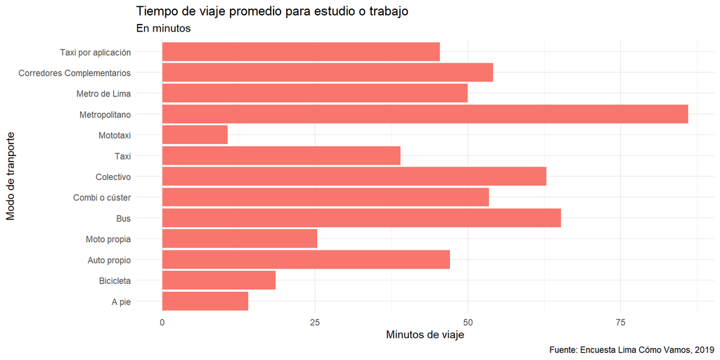

De entre los medios de transporte motorizados, es posible ver que uno de los más rápidos es el auto propio, el cual se diferencia de los medio públicos masivos. Sin embargo, esto va en contra del resultado hallado por Braess (1968) y verificado por Mogridge (1990): en equilibrio, la velocidad promedio de los automóviles es determinada por la velocidad promedio del transporte público. Sin embargo, esto se cumple para situaciones en las que existe capacidad no utilizada de automóbiles privados en un centro urbano dado. Si existe desigualdad en la utilización de automóbiles, esto podría implicar que no existe demanda suprimida de este modo de transporte. Por otra parte, esto podría ser explicado también por que las personas con mayor acceso a automóbiles viven más cerca de su centro de trabajo, en línea con lo mencionado anteriormente, ya que la medida mostrada es de tiempo de viaje, no de velocidad promedio por modo. Esto nos lleva a cuestionar cómo se estructuran las decisiones de modo de transporte según nivel socioeconómico. Para ayudar a responder esta pregunta, está la siguiente figura:

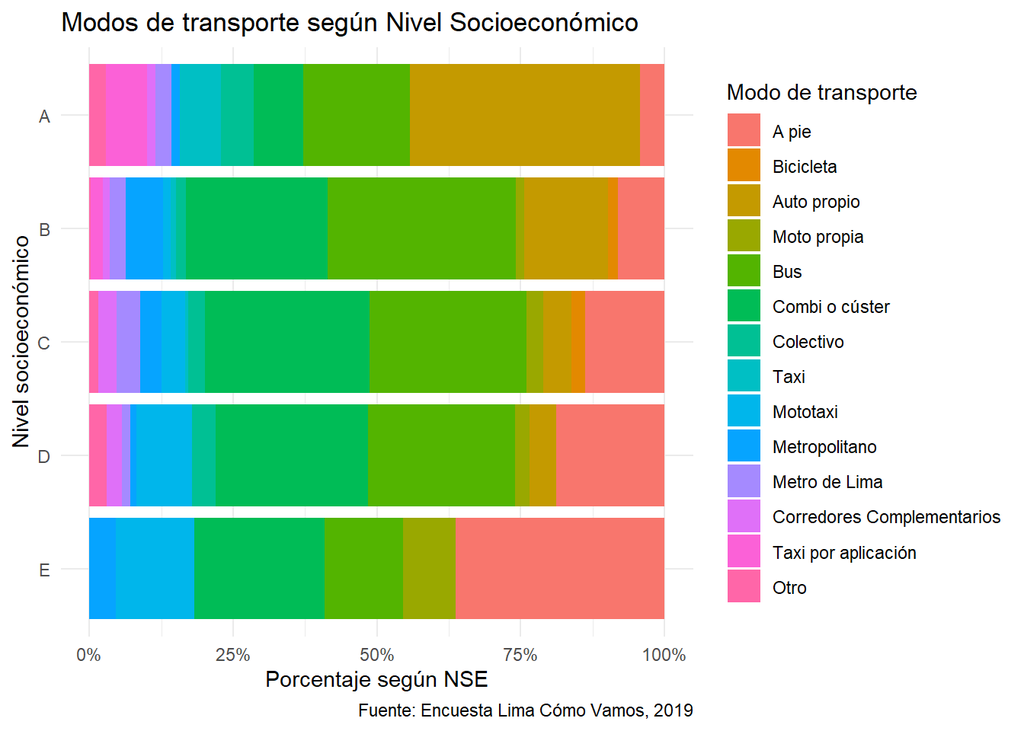

Como podemos ver, el nivel socioeconómico A tiene una utilización mucho mayor de los automóbiles propios, probablemente como resultado de una mayor asequibilidad para este grupo. Por otra parte, es notable que alrededor del 40% de personas en el nivel socioeconómico E se desplazan a pie a sus centros de trabajo o estudio.

## Bibliografía

Alesina, A., Hohmann, S., Michalopoulos, S. y Papaioannou, E. (2019). Intergenerational Mobility in Africa (NBER Working Paper No. 25534). Cambridge: National Bureau of Economic Research.

Braess, D. (1968) Über ein Paradoxon aus der Verkehrsplanung. Unternehmensforschung. Operations Research, 12, 258–268

Pereyra, O. (2006). Forma urbana y segregación en Lima. Debates en Sociología, 31, 69-106.

Mills, E. (1967). An Aggregative Model of Resource Allovation in a Metropolitan Area. The American Economic Review, Papers and Proceedings, 57(2), 197-210

Mogridge, M. J. H. (1990). Travel in towns: jam yesterday, jam today and jam tomorrow? Londres: Palgrave Macmillan

Muth, R. (1969). Cities and Housing: The Spatial Pattern of Urban Residential Land Use. Chicago: University of Chicago Press